# Partie 1 - Analyse en amont : des fichiers FASTQ aux ASV et à la taxonomie

16S rRNA V3-V4 - biopsies bronchiques : cancer du poumon vs témoins sans cancer (NCBI PRJNA586753)

ISBST - Atelier microbiome

09 November 2026

# 1 Avant de commencer

## 1.1 C’est quoi ce document ?

C’est un fichier **R Markdown**. Il mélange du **texte** (les explications), des **blocs de code** (les cases grises que R exécute) et des **résultats** (juste sous chaque bloc). C’est comme un cahier de TP : la consigne, la manipulation, puis le résultat.

- **Avant tout**, ouvrez le projet en double-cliquant sur `Atelier_16S_cancer_poumon.Rproj` : R se place alors dans le bon dossier de travail. Débutant ? Lisez d’abord `GUIDE_DEBUTANT.md` (dans `1_Atelier/`).
- Cliquez sur **Knit** (en haut de l’éditeur RStudio) pour tout lancer et créer un rapport HTML dans `reports/`.
- Ou lancez un bloc à la fois avec la **flèche verte** en haut à droite de chaque case grise.
- Les résultats attendus (tableaux, figures, rapports HTML) sont dans le dossier **`2_Corrige/`**, à côté de ce projet : comparez avec les vôtres à la fin, comme un corrigé de TP.

## 1.2 Qu’allons-nous faire ?

On part des fichiers bruts du séquenceur et on arrive à un tableau qui dit *quelles bactéries* sont dans *quel échantillon* et *combien de lectures* chacune possède.

C’est comme une **chaîne de préparation du couscous** : on part du blé brut, on le trie, on le lave, on le roule, on le sèche… et à la fin on a un produit propre et prêt à l’emploi.

```
FASTQ -> amorces -> contrôle qualité -> filtrage et coupe -> modèle d'erreurs
      -> débruitage (ASV) -> fusion R1 + R2 -> suppression des chimères -> taxonomie (SILVA)
```

## 1.3 Nos échantillons

- **Étude :** microbiote du cancer du poumon central, Saragosse (Espagne), NCBI BioProject PRJNA586753 (Archivos de Bronconeumología, 2020).
- **Échantillons :** **biopsies bronchiques** prises pendant une bronchoscopie.
- **Séquençage :** gène de l’ARNr 16S, **régions V3-V4** (amorces 341F / 805R), Illumina MiSeq, paired-end 2 x 300 pb.
- **Notre sélection : 10 échantillons**
  - **Cancer** = biopsie du bronche atteint par la tumeur, chez 5 patients (TU01 à TU05) ;
  - **Control** = biopsie bronchique de 5 personnes **sans cancer** (HC01 à HC05).
  - La correspondance avec les numéros de l’étude (P02, C05…) est dans `metadata/sample_metadata.tsv` et la méthode de sélection dans `metadata/selection_method.md`.

C’est un plan **cas-témoins** : on compare deux groupes de personnes différentes, comme comparer la taille moyenne des élèves de deux classes.

> **Deux choix faits par le formateur, pour l’atelier :**
> 1. **Moins de lectures.** Chaque échantillon a été réduit au hasard à **5 000 paires de lectures** (graine fixe, R1 et R2 gardés ensemble). C’est comme goûter une cuillère de soupe au lieu de boire toute la marmite : le goût est le même, et ça va beaucoup plus vite sur un ordinateur portable.
> 2. **Des échantillons choisis pour montrer une différence.** Parmi les 25 patients et 16 témoins de l’étude, nous avons gardé les 5 + 5 biopsies dont la composition sépare le mieux les deux groupes. C’est un **choix pédagogique** : il **exagère** la différence. Les p-values de cet atelier servent à apprendre les méthodes, **pas** à conclure sur le cancer du poumon.

> **Important :** une biopsie bronchique contient très peu de bactéries (**faible biomasse microbienne**). Une petite contamination par les réactifs ou le labo peut devenir une grande partie du signal. C’est comme écouter quelqu’un qui chuchote dans une pièce bruyante : le bruit de fond peut couvrir sa voix.

# 2 Étape 1 - Charger les packages

Un package, c’est un appareil qu’on ajoute à la cuisine R. On les “branche” avec `library()`.

```r
library(here)        # retrouver les fichiers dans le projet (comme un GPS pour les dossiers)
library(dada2)       # l'outil principal : des lectures aux ASV
library(ggplot2)     # les figures
library(dplyr)       # manipuler les tableaux
library(tidyr)       # changer la forme des tableaux

packageVersion("dada2")     # on note la version : c'est la reproductibilité
```

```
## [1] '1.38.0'
```

# 3 Étape 2 - Petit contrôle de l’ordinateur

```r
data.frame(
  Item  = c("Project folder", "R version", "Bioconductor", "CPU cores",
            "FASTQ files", "SILVA training set", "SILVA species file"),
  Value = c(basename(here()),     # doit être 1_Atelier : sinon, voir GUIDE_DEBUTANT.md
            R.version.string,
            as.character(BiocManager::version()),
            parallel::detectCores(),
            length(list.files(here("data", "raw_fastq"), pattern = "fastq.gz$")),
            file.exists(here("data", "reference_db", "silva_nr99_v138.1_train_set.fa.gz")),
            file.exists(here("data", "reference_db", "silva_species_assignment_v138.1.fa.gz")))
)
```

```
##                 Item                        Value
## 1     Project folder                    2_Corrige
## 2          R version R version 4.5.2 (2025-10-31)
## 3       Bioconductor                         3.22
## 4          CPU cores                            8
## 5        FASTQ files                           20
## 6 SILVA training set                        FALSE
## 7 SILVA species file                        FALSE
```

## 3.1 Les réglages que vous pouvez changer

Tous les paramètres sont regroupés ici, comme le tableau de bord d’une voiture : on règle tout au même endroit, sans fouiller dans le moteur.

```r
# Utiliser plusieurs coeurs du processeur en même temps ?
# FALSE = un seul coeur : plus lent mais fiable partout. Nos données sont petites,
# donc on garde FALSE. (Sur Mac avec "Knit", TRUE peut bloquer ; sous Windows il est ignoré.)
use_multithread <- FALSE

# Longueur des amorces à retirer au début des lectures (étape 4)
primer_forward <- "CCTACGGGNGGCWGCAG"       # 341F, 17 bases, au début de R1
primer_reverse <- "GACTACHVGGGTATCTAATCC"   # 805R, 21 bases, au début de R2
trim_left <- c(nchar(primer_forward), nchar(primer_reverse))

# Où couper les lectures (en bases, comptées depuis le début de la lecture brute).
# Voir l'étape 5 pour le choix de ces valeurs.
trunc_forward <- 280
trunc_reverse <- 220

# Nombre maximal d'"erreurs attendues" accepté dans une lecture (forward, reverse)
max_expected_errors <- c(2, 2)

# Longueur attendue de la région V3-V4 sans les amorces, en bases (environ)
expected_amplicon <- 427

# Dossiers de sortie
out_dir   <- here("outputs", "01_upstream")
fig_dir   <- here("figures", "01_upstream")
filt_dir  <- here("data", "filtered_fastq")
dir.create(out_dir, recursive = TRUE, showWarnings = FALSE)
dir.create(fig_dir, recursive = TRUE, showWarnings = FALSE)

# set.seed() : les étapes "au hasard" donnent le même résultat à chaque fois,
# comme mélanger un jeu de cartes toujours de la même façon.
set.seed(123)
```

# 4 Étape 3 - Lire et vérifier le tableau des échantillons (métadonnées)

Les fichiers FASTQ ne contiennent que des lectures d’ADN. Le tableau des **métadonnées** dit quel échantillon vient d’un patient avec cancer et lequel vient d’un témoin. C’est l’**étiquette du tube**. Si l’étiquette est fausse, **tous** les résultats sont faux : on la vérifie donc en premier, comme un pharmacien qui vérifie l’ordonnance avant de donner le médicament.

```r
metadata <- read.delim(here("metadata", "sample_metadata.tsv"), stringsAsFactors = FALSE)

# "Control" est le groupe de référence : les statistiques compareront Cancer à Control
metadata$group <- factor(metadata$group, levels = c("Control", "Cancer"))

knitr::kable(metadata[, c("sample_id", "run_accession", "group", "subject_id",
                          "sample_type", "original_read_count")])
```

| sample_id | run_accession | group | subject_id | sample_type | original_read_count |
| --- | --- | --- | --- | --- | --- |
| HC01 | SRR10376841 | Control | C05 | bronchial biopsy | 28881 |
| HC02 | SRR10376818 | Control | C14 | bronchial biopsy | 24717 |
| HC03 | SRR10376887 | Control | C01 | bronchial biopsy | 21309 |
| HC04 | SRR10376875 | Control | C06 | bronchial biopsy | 24146 |
| HC05 | SRR10376827 | Control | C10 | bronchial biopsy | 18977 |
| TU01 | SRR10376788 | Cancer | P02 | bronchial biopsy | 21291 |
| TU02 | SRR10376871 | Cancer | P17 | bronchial biopsy | 108828 |
| TU03 | SRR10376850 | Cancer | P09 | bronchial biopsy | 72997 |
| TU04 | SRR10376880 | Cancer | P15 | bronchial biopsy | 44570 |
| TU05 | SRR10376792 | Cancer | P01 | bronchial biopsy | 14000 |

```r
# Noms de fichiers attendus pour chaque échantillon
# Chaque fichier porte le nom de son échantillon : TU01_R1.fastq.gz, HC03_R2.fastq.gz...
# (le numéro d'origine dans la base SRA reste dans la colonne run_accession)
metadata$fastq_R1 <- paste0(metadata$sample_id, "_R1.fastq.gz")
metadata$fastq_R2 <- paste0(metadata$sample_id, "_R2.fastq.gz")

# Une liste de contrôles, comme la check-list d'un pilote avant le décollage
checks <- data.frame(
  Check = c("Sample IDs are unique",
            "Only 'Control' and 'Cancer' groups",
            "5 samples in each group",
            "One sample per person",
            "Every sample has its R1 file",
            "Every sample has its R2 file"),
  Result = c(!any(duplicated(metadata$sample_id)),
             all(!is.na(metadata$group)),
             all(table(metadata$group) == 5),
             !any(duplicated(metadata$subject_id)),
             all(file.exists(here("data", "raw_fastq", metadata$fastq_R1))),
             all(file.exists(here("data", "raw_fastq", metadata$fastq_R2))))
)
knitr::kable(checks)
```

| Check | Result |
| --- | --- |
| Sample IDs are unique | TRUE |
| Only ‘Control’ and ‘Cancer’ groups | TRUE |
| 5 samples in each group | TRUE |
| One sample per person | TRUE |
| Every sample has its R1 file | TRUE |
| Every sample has its R2 file | TRUE |

```r
# Si un contrôle échoue, on s'arrête ici avec un message clair
if (!all(checks$Result)) stop("A metadata check failed: fix the table before continuing.")
```

**Comment lire ce résultat :** chaque ligne doit être `TRUE`. Si une ligne est `FALSE`, le document s’arrête, car un mauvais tableau d’échantillons donnerait une fausse biologie.

# 5 Étape 4 - Les fichiers FASTQ et les amorces

Un fichier FASTQ range chaque lecture sur **4 lignes**, comme une fiche :

1. `@nom` de la lecture (le nom sur la fiche)
2. la **séquence** d’ADN (A, C, G, T)
3. `+` (un séparateur)
4. la **qualité** de chaque base, écrite avec un caractère par base

```r
# Chemins complets des fichiers, dans le même ordre que le tableau des métadonnées
fnFs <- here("data", "raw_fastq", metadata$fastq_R1)   # lectures forward (R1)
fnRs <- here("data", "raw_fastq", metadata$fastq_R2)   # lectures reverse (R2)
sample_names <- metadata$sample_id

# Afficher la première lecture du premier échantillon
readLines(gzfile(fnFs[1]), n = 4)
```

```
## [1] "@SRR10376841.4 4 length=300"
## [2] "NCTACGGGTGGCAGCCTGCTCCTGTCTGGGAGAGGGCTGGGCAGACACTGGGAGCCGGGC…"
## [3] "+SRR10376841.4 4 length=300"
## [4] "#8BCCGGGGGGGGGGGGGGGGGGGGGGCFFF;FFGGGGGGGGGGGGGGCCFFGGGGGGGEGGGGGGGGGGGGGGGGGGG,F@CFGGGGGGGGGGGGEGDFGCGGGGGFGGDGGGGGDGGGGGG,<F8FFGGDGGGGGDD@FC>><FC*@FEGGGGFFD,,>D7:FGCCCF=B<2,*+4818;<*<CFB8CE**:5*:CF?C67CG6:;5=F*2*<7CF6+7;*::C5=<57:C*8/8))/*.9@)05)))))04B>@6*,)()(-)400-.85()443(.))))))-(((-)…
```

## 5.1 Les amorces sont-elles bien au début de chaque lecture ?

Les amorces contiennent des **bases dégénérées** : `N` = n’importe quelle base, `W` = A ou T, `H` = A, C ou T, `V` = A, C ou G. C’est comme un mot de passe où certaines lettres peuvent changer. On transforme ces lettres en “jokers” pour les chercher.

```r
# Transformer une amorce avec bases dégénérées en motif de recherche (expression régulière)
iupac_to_regex <- function(p) {
  codes <- c(N = "[ACGT]", W = "[AT]", H = "[ACT]", V = "[ACG]", R = "[AG]", Y = "[CT]",
             S = "[CG]", K = "[GT]", M = "[AC]", B = "[CGT]", D = "[AGT]")
  paste0("^", paste(sapply(strsplit(p, "")[[1]], function(b) ifelse(b %in% names(codes), codes[b], b)),
                    collapse = ""))
}
percent_with_primer <- function(file, primer, n = 2000) {
  reads <- as.character(ShortRead::sread(ShortRead::yield(ShortRead::FastqStreamer(file, n))))
  round(100 * mean(grepl(iupac_to_regex(primer), reads)), 1)
}
primer_table <- data.frame(Sample = sample_names, Group = metadata$group,
                           R1_starts_with_341F = sapply(fnFs, percent_with_primer, primer_forward),
                           R2_starts_with_805R = sapply(fnRs, percent_with_primer, primer_reverse),
                           row.names = NULL)
knitr::kable(primer_table)
```

| Sample | Group | R1_starts_with_341F | R2_starts_with_805R |
| --- | --- | --- | --- |
| HC01 | Control | 26.7 | 28.5 |
| HC02 | Control | 28.4 | 31.0 |
| HC03 | Control | 40.7 | 27.2 |
| HC04 | Control | 82.2 | 84.6 |
| HC05 | Control | 40.8 | 39.8 |
| TU01 | Cancer | 74.9 | 74.3 |
| TU02 | Cancer | 88.1 | 92.0 |
| TU03 | Cancer | 76.6 | 75.6 |
| TU04 | Cancer | 62.8 | 58.9 |
| TU05 | Cancer | 75.6 | 76.8 |

**Comment lire ce résultat :** le pourcentage de lectures qui commencent **exactement** par l’amorce. Les amorces sont toujours en position 0 (au tout début), donc on peut simplement couper les 17 premières bases de R1 et les 21 premières de R2 (`trimLeft`). Le pourcentage n’est pas 100 % : certaines lectures ont une petite erreur dans l’amorce, et d’autres viennent d’ADN **hors cible** (ADN humain amplifié par erreur), surtout quand il y a peu de bactéries. Comparez les deux groupes : les biopsies des témoins ont souvent encore moins d’ADN bactérien.

> Avec des amorces à des positions variables, on utiliserait l’outil `cutadapt`.

# 6 Étape 5 - Contrôle qualité : où couper les lectures ?

Le score de qualité **Q** dit à quel point la machine est sûre de chaque base : Q30 = 1 erreur sur 1 000 bases, Q20 = 1 sur 100. C’est comme quelqu’un qui lit une écriture manuscrite : au début de la page il lit bien, à la fin il est fatigué et se trompe plus. Sur MiSeq, la qualité est haute au début et baisse à la fin, surtout pour **R2**.

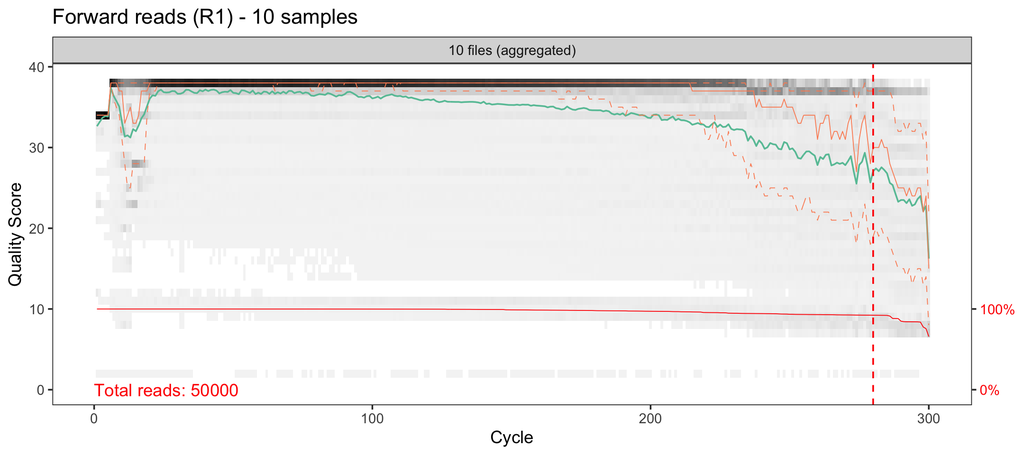

```r
# plotQualityProfile() dessine la qualité à chaque position de la lecture
# (ligne verte = qualité moyenne, orange = médiane et quartiles)
# aggregate = TRUE : un seul graphique pour tous les échantillons
plotQualityProfile(fnFs, aggregate = TRUE) + ggtitle("Forward reads (R1) - 10 samples") +
  geom_vline(xintercept = trunc_forward, colour = "red", linetype = "dashed")
```

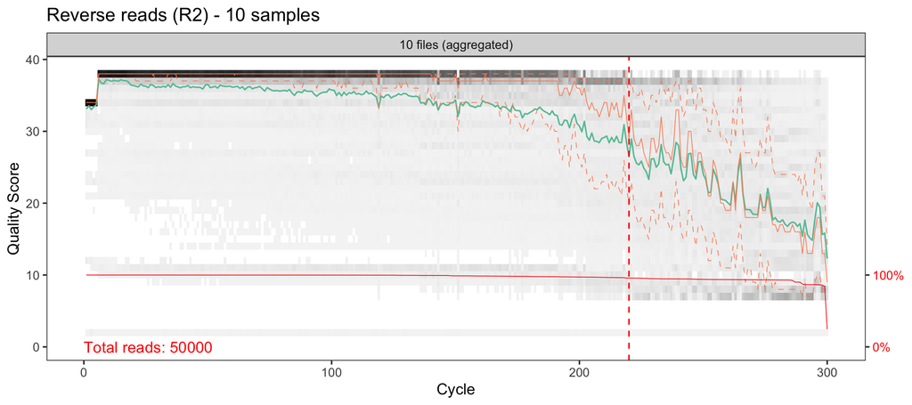

```r
plotQualityProfile(fnRs, aggregate = TRUE) + ggtitle("Reverse reads (R2) - 10 samples") +
  geom_vline(xintercept = trunc_reverse, colour = "red", linetype = "dashed")
```

**Comment lire ces graphiques :** la ligne rouge en pointillé montre où nous coupons. Pour R1, la qualité reste bonne (au-dessus de Q30) jusqu’à environ 270 bases. Pour R2, elle baisse plus tôt, vers 210-230 bases. On coupe donc **R1 à 280** et **R2 à 220**, là où la qualité médiane commence à descendre. C’est comme couper le bout abîmé d’une baguette de pain : on garde la partie bonne.

## 6.1 La règle d’or : garder assez de chevauchement

Après la coupe, R1 et R2 doivent encore **se chevaucher** pour que DADA2 puisse les recoller. C’est comme deux photos d’un panorama : pour les assembler, il faut une partie commune aux deux. DADA2 a besoin d’au moins 12 bases communes ; 20 ou plus, c’est plus sûr.

```r
# Ce qui reste après la coupe ET le retrait des amorces
kept_forward <- trunc_forward - trim_left[1]
kept_reverse <- trunc_reverse - trim_left[2]
overlap <- kept_forward + kept_reverse - expected_amplicon
data.frame(R1_kept = kept_forward, R2_kept = kept_reverse,
           Amplicon_without_primers = expected_amplicon, Overlap = overlap,
           Enough_overlap = overlap >= 20)
```

```
##   R1_kept R2_kept Amplicon_without_primers Overlap Enough_overlap
## 1     263     199                      427      35           TRUE
```

**Comment lire ce résultat :** il reste 263 bases de R1 et 199 de R2, soit 462 bases pour couvrir un amplicon d’environ 427 bases : le chevauchement est d’environ 35 bases. C’est assez, mais pas énorme : la région V3-V4 est longue. **Exercice :** que se passe-t-il si on coupe R2 à 180 ?

# 7 Étape 6 - Filtrer et couper les lectures

`filterAndTrim()` nettoie les lectures, comme on trie les lentilles avant la cuisson pour enlever les petits cailloux :

- `trimLeft` : retirer les amorces au début de R1 et R2 ;
- `truncLen` : couper chaque lecture à la longueur choisie (les lectures plus courtes sont retirées) ;
- `maxN = 0` : retirer les lectures avec des bases inconnues (N), DADA2 ne les accepte pas ;
- `maxEE` : retirer les lectures avec trop d’**erreurs attendues** (calculées à partir de la qualité) ;
- `rm.phix = TRUE` : retirer les lectures de PhiX, un virus témoin ajouté pendant le séquençage.

```r
# Noms des fichiers nettoyés que DADA2 va créer
filtFs <- file.path(filt_dir, paste0(sample_names, "_F_filt.fastq.gz"))
filtRs <- file.path(filt_dir, paste0(sample_names, "_R_filt.fastq.gz"))
names(filtFs) <- sample_names
names(filtRs) <- sample_names

filter_out <- filterAndTrim(fnFs, filtFs, fnRs, filtRs,
                            trimLeft    = trim_left,
                            truncLen    = c(trunc_forward, trunc_reverse),
                            maxN        = 0,
                            maxEE       = max_expected_errors,
                            truncQ      = 2,
                            rm.phix     = TRUE,
                            compress    = TRUE,
                            multithread = use_multithread)

rownames(filter_out) <- sample_names
filter_table <- data.frame(Sample = sample_names, Group = metadata$group,
                           Reads_in  = filter_out[, "reads.in"],
                           Reads_out = filter_out[, "reads.out"],
                           Percent_kept = round(100 * filter_out[, "reads.out"] /
                                                  filter_out[, "reads.in"], 1))
knitr::kable(filter_table, row.names = FALSE)
```

| Sample | Group | Reads_in | Reads_out | Percent_kept |
| --- | --- | --- | --- | --- |
| HC01 | Control | 5000 | 2828 | 56.6 |
| HC02 | Control | 5000 | 2844 | 56.9 |
| HC03 | Control | 5000 | 2400 | 48.0 |
| HC04 | Control | 5000 | 4043 | 80.9 |
| HC05 | Control | 5000 | 3077 | 61.5 |
| TU01 | Cancer | 5000 | 3289 | 65.8 |
| TU02 | Cancer | 5000 | 3783 | 75.7 |
| TU03 | Cancer | 5000 | 3409 | 68.2 |
| TU04 | Cancer | 5000 | 3140 | 62.8 |
| TU05 | Cancer | 5000 | 3196 | 63.9 |

**Comment lire ce résultat :** `Percent_kept` est le pourcentage de lectures qui ont passé le filtre. Avec de vraies données MiSeq 2 x 300, garder 60 à 80 % est normal : la fin de R2 est souvent de mauvaise qualité, et `maxEE` retire les lectures avec trop d’erreurs probables.

# 8 Étape 7 - Apprendre les taux d’erreur

Les séquenceurs font des erreurs. DADA2 **apprend** à quelle fréquence chaque base est mal lue (par exemple un A lu comme un G) **en fonction du score de qualité**, à partir des données elles-mêmes. C’est comme une enseignante qui connaît les fautes habituelles d’un élève : si elle sait qu’il confond souvent “b” et “d” quand il écrit vite, elle peut deviner le mot juste.

```r
errF <- learnErrors(filtFs, multithread = use_multithread)
```

```
## 8418367 total bases in 32009 reads from 10 samples will be used for learning the error rates.
```

```r
errR <- learnErrors(filtRs, multithread = use_multithread)
```

```
## 6369791 total bases in 32009 reads from 10 samples will be used for learning the error rates.
```

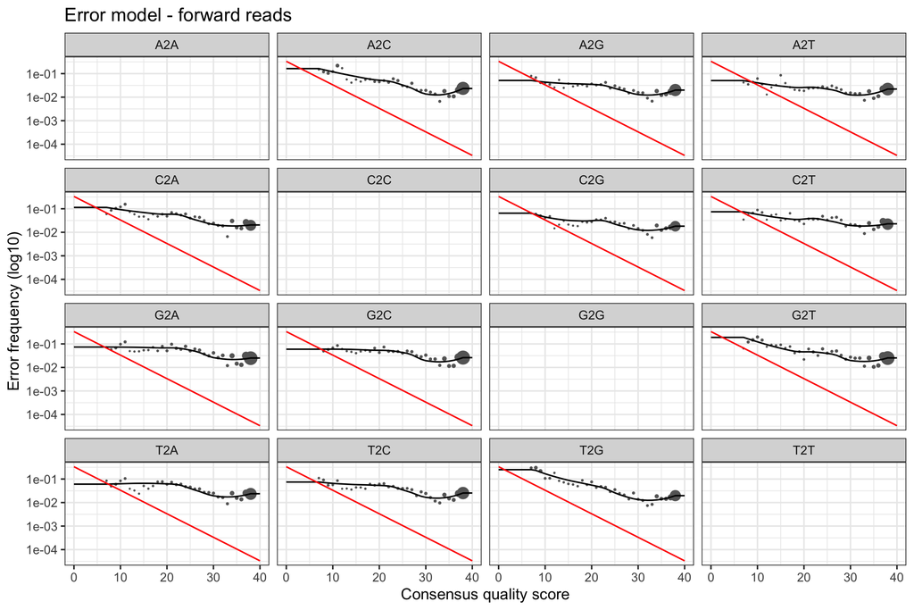

```r
plotErrors(errF, nominalQ = TRUE) + ggtitle("Error model - forward reads")
```

**Comment lire ce graphique :** chaque petit panneau est un type d’erreur (A2G = A lu comme G…). Les points noirs sont les erreurs observées, la ligne noire est le modèle appris par DADA2, et la ligne rouge est ce que le score de qualité “promet”. Un bon modèle : la ligne noire suit les points, et le taux d’erreur **diminue** quand la qualité augmente (à droite).

# 9 Étape 8 - Débruitage : trouver les vraies séquences (ASV)

`dada()` utilise le modèle d’erreurs pour décider, pour chaque séquence unique, si c’est une **vraie** séquence ou une **erreur** d’une séquence plus abondante.

Exemple de la vie courante : si 1 000 personnes écrivent “Tunis” et 3 personnes écrivent “Tumis”, on comprend que “Tumis” est une faute de frappe de “Tunis”, pas une nouvelle ville. Mais si 300 personnes écrivent “Sousse”, c’est une vraie ville différente.

Les vraies séquences s’appellent des **ASV** (*Amplicon Sequence Variants*) : des séquences d’ADN exactes, qui peuvent différer d’une seule base. (Les anciennes méthodes regroupaient les séquences en OTU à 97 % de similarité, comme ranger “Tunis” et “Tunisie” dans la même boîte.)

`pool = "pseudo"` permet à DADA2 de partager l’information entre échantillons, ce qui aide à détecter les séquences rares : utile pour les échantillons à faible biomasse.

```r
dadaFs <- dada(filtFs, err = errF, pool = "pseudo", multithread = use_multithread)
```

```
## Sample 1 - 2828 reads in 1743 unique sequences.
## Sample 2 - 2844 reads in 1742 unique sequences.
## Sample 3 - 2400 reads in 1559 unique sequences.
## Sample 4 - 4043 reads in 1121 unique sequences.
## Sample 5 - 3077 reads in 1701 unique sequences.
## Sample 6 - 3289 reads in 1652 unique sequences.
## Sample 7 - 3783 reads in 1579 unique sequences.
## Sample 8 - 3409 reads in 1552 unique sequences.
## Sample 9 - 3140 reads in 1725 unique sequences.
## Sample 10 - 3196 reads in 1731 unique sequences.
##
##    selfConsist step 2
```

```r
dadaRs <- dada(filtRs, err = errR, pool = "pseudo", multithread = use_multithread)
```

```
## Sample 1 - 2828 reads in 1973 unique sequences.
## Sample 2 - 2844 reads in 1804 unique sequences.
## Sample 3 - 2400 reads in 1593 unique sequences.
## Sample 4 - 4043 reads in 1315 unique sequences.
## Sample 5 - 3077 reads in 1718 unique sequences.
## Sample 6 - 3289 reads in 1495 unique sequences.
## Sample 7 - 3783 reads in 1417 unique sequences.
## Sample 8 - 3409 reads in 1520 unique sequences.
## Sample 9 - 3140 reads in 1699 unique sequences.
## Sample 10 - 3196 reads in 1416 unique sequences.
##
##    selfConsist step 2
```

```r
# Exemple : ce que DADA2 a trouvé dans le premier échantillon
dadaFs[[1]]
```

```
## dada-class: object describing DADA2 denoising results
## 299 sequence variants were inferred from 1743 input unique sequences.
## Key parameters: OMEGA_A = 1e-40, OMEGA_C = 1e-40, BAND_SIZE = 16
```

**Comment lire ce résultat :** DADA2 indique combien de vrais variants de séquence il a trouvés, à partir de combien de séquences uniques, dans le premier échantillon.

# 10 Étape 9 - Fusionner les lectures forward et reverse

Chaque R1 et son R2 viennent de la **même** molécule d’ADN, lue par les deux bouts. Comme elles se chevauchent, DADA2 peut les recoller en une seule séquence plus longue qui couvre toute la région V3-V4. C’est comme recoller les deux moitiés d’un billet déchiré : la partie commune permet de les aligner parfaitement.

```r
mergers <- mergePairs(dadaFs, filtFs, dadaRs, filtRs, minOverlap = 12, verbose = FALSE)

# Combien de paires de lectures ont été fusionnées dans chaque échantillon ?
sapply(mergers, function(x) sum(x$abundance))
```

```
## HC01 HC02 HC03 HC04 HC05 TU01 TU02 TU03 TU04 TU05
## 1205 1363 1169 3753 1852 2591 3320 2709 2198 2582
```

# 11 Étape 10 - Construire la table des ASV

La **table des ASV** est le résultat central : une **ligne par échantillon**, une **colonne par ASV**, et dans chaque case le **nombre de lectures**. C’est comme le registre de présence d’une école : une ligne par classe, une colonne par élève, et dans la case le nombre de jours de présence.

```r
seqtab <- makeSequenceTable(mergers)
dim(seqtab)     # nombre d'échantillons, nombre d'ASV
```

```
## [1]  10 628
```

```r
# Longueur des séquences ASV : elles doivent être proches de la longueur de V3-V4
table(nchar(getSequences(seqtab)))
```

```
##
## 263 264 268 269 270 271 272 273 274 278 280 284 285 286 287 288 289 290 291 292
##  37   1   3   2   1   1   1   6   3   2   1   1   1   1   2   1   3   4   1   1
## 294 295 296 297 298 300 303 304 305 306 307 308 309 310 311 312 313 314 316 317
##   3   1   6   2   2   1   2   2   2   2   1   2   3   1   2   2   2   2   2   1
## 320 321 322 324 326 328 330 332 333 334 336 337 338 341 342 344 345 346 347 348
##   3   1   1   1   3   1   1   3   1   2   1   2   2   2   3   2   1   2   1   1
## 349 351 353 354 357 359 363 365 366 367 368 369 370 371 372 373 374 375 377 378
##   3   1   1   4   1   2   1   2   2   3   3   1   1   1   1   1   2   1   5   1
## 379 380 381 382 383 384 385 391 392 393 395 396 397 400 401 402 403 404 405 406
##   2   2   1   1   2   1   3   2   1   2   1   1   5   1  13  59  17  22  23   3
## 407 408 409 410 411 413 414 415 416 418 419 420 421 422 423 424 425 426 427 428
##   9   7   2   1   1   1   2   1   4   1   2   5   6  64   9   1   4  11 114  12
## 429 431 432 433 434 436 437 438 441 443 445 446 447 448 449 450
##   1   1   2   2   1   2   1   3   1   1   2   1   2   2   1   1
```

**Comment lire ce résultat :** la longueur de V3-V4 varie un peu d’une bactérie à l’autre (environ 400 à 430 bases sans les amorces). Les séquences beaucoup plus courtes ou plus longues sont souvent des produits non spécifiques. On garde seulement les longueurs plausibles.

```r
keep_length <- nchar(getSequences(seqtab)) %in% 400:432
seqtab <- seqtab[, keep_length]
dim(seqtab)
```

```
## [1]  10 399
```

# 12 Étape 11 - Retirer les chimères

Pendant la PCR, deux ADN différents peuvent se coller et former une **chimère** : une séquence artificielle, moitié d’une bactérie et moitié d’une autre. Elle n’existe pas dans la nature. Le nom vient de la Chimère de la mythologie, mi-lion mi-chèvre. C’est aussi comme un photomontage avec la tête d’une personne sur le corps d’une autre : ça ressemble à une vraie photo, mais cette personne n’existe pas. DADA2 les repère comme des séquences qu’on peut reconstruire à partir de deux “parents” plus abondants.

```r
seqtab_nochim <- removeBimeraDenovo(seqtab, method = "consensus",
                                    multithread = use_multithread, verbose = TRUE)

data.frame(
  ASVs_before = ncol(seqtab),
  ASVs_after  = ncol(seqtab_nochim),
  Percent_reads_kept = round(100 * sum(seqtab_nochim) / sum(seqtab), 1)
)
```

```
##   ASVs_before ASVs_after Percent_reads_kept
## 1         399        379               98.5
```

**Comment lire ce résultat :** les chimères sont souvent nombreuses en ASV mais faibles en lectures. Garder plus de 80-90 % des lectures est normal. Si beaucoup de lectures sont perdues, les amorces sont peut-être encore présentes.

# 13 Étape 12 - Suivre les lectures tout au long du pipeline

On suit le nombre de lectures de chaque échantillon à chaque étape. C’est comme compter les passagers d’un bus à chaque arrêt : si le nombre chute d’un coup, on sait à quel arrêt le problème est arrivé.

```r
getN <- function(x) sum(getUniques(x))    # petite aide : nombre total de lectures dans un objet DADA2

track <- data.frame(
  Sample       = sample_names,
  Group        = metadata$group,
  Input        = filter_out[, "reads.in"],
  Filtered     = filter_out[, "reads.out"],
  Denoised_F   = sapply(dadaFs, getN),
  Denoised_R   = sapply(dadaRs, getN),
  Merged       = sapply(mergers, getN),
  Non_chimeric = rowSums(seqtab_nochim)
)
track$Percent_final <- round(100 * track$Non_chimeric / track$Input, 1)

knitr::kable(track, row.names = FALSE)
```

| Sample | Group | Input | Filtered | Denoised_F | Denoised_R | Merged | Non_chimeric | Percent_final |
| --- | --- | --- | --- | --- | --- | --- | --- | --- |
| HC01 | Control | 5000 | 2828 | 1890 | 1701 | 1205 | 404 | 8.1 |
| HC02 | Control | 5000 | 2844 | 1884 | 1831 | 1363 | 476 | 9.5 |
| HC03 | Control | 5000 | 2400 | 1612 | 1554 | 1169 | 762 | 15.2 |
| HC04 | Control | 5000 | 4043 | 3952 | 3929 | 3753 | 3442 | 68.8 |
| HC05 | Control | 5000 | 3077 | 2386 | 2287 | 1852 | 1221 | 24.4 |
| TU01 | Cancer | 5000 | 3289 | 2878 | 2917 | 2591 | 2034 | 40.7 |
| TU02 | Cancer | 5000 | 3783 | 3535 | 3554 | 3320 | 2357 | 47.1 |
| TU03 | Cancer | 5000 | 3409 | 2934 | 3008 | 2709 | 2457 | 49.1 |
| TU04 | Cancer | 5000 | 3140 | 2531 | 2498 | 2198 | 1790 | 35.8 |
| TU05 | Cancer | 5000 | 3196 | 2830 | 2845 | 2582 | 1967 | 39.3 |

```r
write.csv(track, file.path(out_dir, "read_tracking.csv"), row.names = FALSE)
```

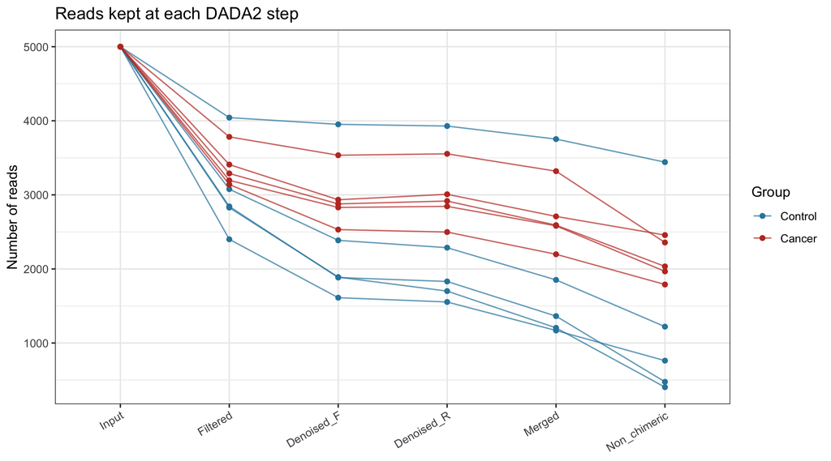

```r
track_long <- pivot_longer(track, cols = Input:Non_chimeric,
                           names_to = "Step", values_to = "Reads")
track_long$Step <- factor(track_long$Step,
                          levels = c("Input", "Filtered", "Denoised_F", "Denoised_R",
                                     "Merged", "Non_chimeric"))

p_track <- ggplot(track_long, aes(x = Step, y = Reads, group = Sample, colour = Group)) +
  geom_line(alpha = 0.7) + geom_point(size = 1.5) +
  scale_colour_manual(values = c(Control = "#2E86AB", Cancer = "#C0392B")) +
  labs(title = "Reads kept at each DADA2 step", x = NULL, y = "Number of reads") +
  theme_bw() + theme(axis.text.x = element_text(angle = 30, hjust = 1))
p_track
```

```r
ggsave(file.path(fig_dir, "read_tracking.png"), p_track, width = 8, height = 5, dpi = 300)
ggsave(file.path(fig_dir, "read_tracking.pdf"), p_track, width = 8, height = 5)
```

**Comment lire ce graphique :** chaque ligne est un échantillon. Une chute brutale montre l’étape où les lectures ont été perdues : à *Filtered* (coupe trop longue, mauvaise qualité), à *Merged* (pas assez de chevauchement) ou à *Non_chimeric* (chimères, ou séquences de longueur non plausible retirées à l’étape 10, souvent de l’ADN humain hors cible). Une ligne régulière, qui garde la plupart des lectures, veut dire que le pipeline a bien marché.